# Practical Machine Learning - Measuring Proper Form During Execise

c-spohrer

06/18/2014

**SYNOPSIS**

We apply random forests as a machine learning tool to measurements of arm motion while a subject performs bicep curls to classify whether they have performed the exercise correctly.

**DATA SET**

The data set consists of measurements from 6 participants as to how well they performed dumbell exercises. The acceleromters that recorded the measurements were attached to variuous parts of their arms. The particpants performed the Bicep Curl in 1 correct method and in 4 specific incorrect methods, resulting in 5 classes that will be predicted from the measurements.

The correct class is Class A, the incorrect, but distinct classes are B, C, D and E.

There are 159 independent variables, of which nearly 100 variables are descriptive statistics of the other fields, and so will be eliminated from the model.

**APPROACH**

We will use the caret pacakge and the R statistical language to perform our analysis and to model our predictions. The data is provided as one file for training, and a smaller file of 20 records for validation and submission for grading purposes.

For our purposes, we split the training file into a training set of 70% of the records, and a testing set with the remaining 30% of the observations, leaving the 20 records in the seperate testing file as our validation set.

**PRE-PROCESSING**

The classification variable is ‘classe’ and consists of the values: A, B, C, D, E; with A = correct performance of the exercise, and the others correspond to intentionally performing the exercise wrong.

The first 7 independent variables are descriptive of the observation, and so will be eliminated. They are: * raw_timestamp_part_1 * raw_timestamp_part_2 * cvtd_timestamp * new_window * num_window

Eliminating these variables also had the added benefit of eliminated any problems with missing values.

**EXPERIMENT**

The following analysis, code and results hightlight the steps taken to apply the random forest machine learning technique to the data set. The data is prepared, split into training and testing sets, the algorithm applied, classification results reported, and the model applied to a held-out set of twenty observations.

```r
# analysis
# setwd("~/Documents/online-learning/data-science-practical-machine-learning-2014/code")

# read in the data sets
testing <- read.csv("pml-testing.csv")
training <- read.csv("pml-training.csv", na.strings=c("","NA"))

dim(training)
```

```
## [1] 19622   160
```

```r
dim(testing)
```

```
## [1]  20 160
```

```r
# take a closer look at the data
# str(training)
# require(Hmisc)
# describe(training)




# let's try getting rid of the summary statistics columns first
# determine which columns have a lot of NA's'

 idx<-apply(training, 2, function(x) sum(is.na(x)))

# describe(idx)

# RESULTS: this shows that there were 60 columns that had values for every observation,
# and 100 columns with 19216 NA's in that column
# so create a column index of which columns to keep

keepthesecolumns <- ifelse(idx == 0, TRUE, FALSE)

# new training set without the columns of summary statistics

training2 <- training[,keepthesecolumns]
testing2 <- testing[, keepthesecolumns]
dim(training2)
```

```
## [1] 19622    60
```

```r
dim(testing2)
```

```
## [1] 20 60
```

```r
#str(training2)
#str(testing2)

# now get rid of the first 7 fields - since these were descriptive as well
training3 <- training2[,8:ncol(training2)]
testing3 <- testing2[,8:ncol(testing2)]
dim(training3)
```

```
## [1] 19622    53
```

```r
dim(testing3)
```

```
## [1] 20 53
```

```r
# now turn the class variable 'classe' into a factor
training3$classe <- factor(as.character( training3$classe) )

# since randomforest takes a long time,
# let's train against smaller subsets for testing purposes

TEST =  FALSE # TRUE # FALSE
if(TEST) {
index <- sample(nrow(training),size=500, replace= FALSE )
training3 <- training3[ index, ]
dim(training3)
}


# Split into a training set, and a testing set,
# and save the 20 obs as a validation set


library(caret)
# create trainSet, testSet, validationSet
inTrain <- createDataPartition( y=training3$classe, p=0.7,  list=FALSE)
trainSet <- training3[inTrain, ]
testSet <- training3[-inTrain, ]
validationSet <- testing3

dim(trainSet)
```

```
## [1] 13737    53
```

```r
dim(testSet)
```

```
## [1] 5885   53
```

```r
dim(validationSet)
```

```
## [1] 20 53
```

```r
set.seed(12345)

# use out-of-bag sampling instead of cross-validation to find the
# best choice of paramters, ie. mtry
ctrl <- trainControl(method="oob", number=5)
modelFit <- train(classe~., data=trainSet, method="rf",
                  trControl=ctrl, ntree=500, tuneLength=5, metric="Accuracy")
modelFit
```

[output not shown]

```r
pred <- predict(modelFit, trainSet)
print("Model accuracy based on training set")
```

```
## [1] "Model accuracy based on training set"
```

```r
table(pred, trainSet$classe)
```

```
##
## pred    A    B    C    D    E
##    A 3906    0    0    0    0
##    B    0 2658    0    0    0
##    C    0    0 2396    0    0
##    D    0    0    0 2252    0
##    E    0    0    0    0 2525
```

```r
pred <- predict(modelFit, testSet)
print("Model accuracy based on held out testing set")
```

```
## [1] "Model accuracy based on held out testing set"
```

```r
table(pred, testSet$classe)
```

```
##
## pred    A    B    C    D    E
##    A 1672    6    0    0    0
##    B    0 1133    4    0    0
##    C    1    0 1021    4    4
##    D    0    0    1  959    2
##    E    1    0    0    1 1076
```

```r
# confusion matrix

cm <- confusionMatrix(data= pred,  # predicted results
                reference= testSet$classe  )    # true results
cm
```

```
## Confusion Matrix and Statistics
##
##           Reference
## Prediction    A    B    C    D    E
##          A 1672    6    0    0    0
##          B    0 1133    4    0    0
##          C    1    0 1021    4    4
##          D    0    0    1  959    2
##          E    1    0    0    1 1076
##
## Overall Statistics
##
##                Accuracy : 0.996
##                  95% CI : (0.994, 0.997)
##     No Information Rate : 0.284
##     P-Value [Acc > NIR] : <2e-16
##
##                   Kappa : 0.995
##  Mcnemar's Test P-Value : NA
##
## Statistics by Class:
##
##                      Class: A Class: B Class: C Class: D Class: E
## Sensitivity             0.999    0.995    0.995    0.995    0.994
## Specificity             0.999    0.999    0.998    0.999    1.000
## Pos Pred Value          0.996    0.996    0.991    0.997    0.998
## Neg Pred Value          1.000    0.999    0.999    0.999    0.999
## Prevalence              0.284    0.194    0.174    0.164    0.184
## Detection Rate          0.284    0.193    0.173    0.163    0.183
## Detection Prevalence    0.285    0.193    0.175    0.163    0.183
## Balanced Accuracy       0.999    0.997    0.997    0.997    0.997
```

```r
myAccuracy <- cm$overall["Accuracy"] * 100
myAccuracy <- as.character(round(myAccuracy, 2))


# look at variable importance

# Report on the variables with the most importance
varImp(modelFit)
```

```
## rf variable importance
##
##   only 20 most important variables shown (out of 52)
##
##                      Overall
## roll_belt              100.0
## yaw_belt                64.3
## pitch_forearm           61.1
## magnet_dumbbell_z       52.9
## pitch_belt              49.9
## magnet_dumbbell_y       48.9
## roll_forearm            41.6
## roll_dumbbell           24.6
## magnet_dumbbell_x       24.5
## accel_dumbbell_y        23.4
## accel_belt_z            23.0
## magnet_belt_z           21.6
## magnet_belt_y           20.3
## accel_forearm_x         19.0
## accel_dumbbell_z        17.6
## magnet_forearm_z        16.2
## roll_arm                15.3
## gyros_belt_z            14.8
## total_accel_dumbbell    13.9
## yaw_arm                 13.6
```

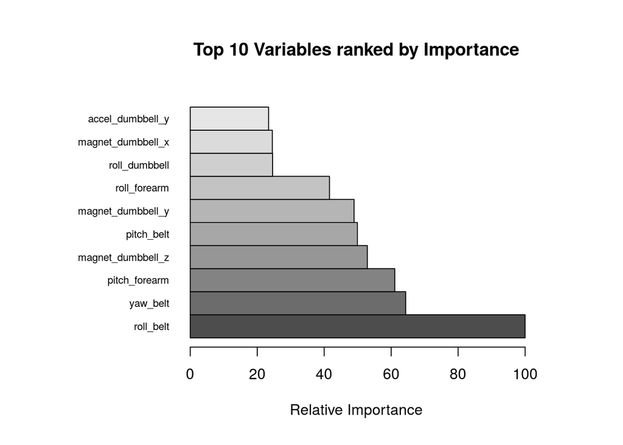

```r
varlist <- varImp(modelFit)

# plot those variables with the  most importance
vli <- varlist$importance[ order(varlist$importance$Overall, decreasing=TRUE), ,drop=FALSE]
numShown <- 10
myBars <- as.matrix(vli[1:numShown,])
myNames <- rownames(vli)[1:numShown]

op <- par(no.readonly = TRUE) # the whole list of settable par's.
par(mai=c(1,2,1,1)+0.1 ) # expand left margin)

barplot(myBars,
        horiz=TRUE,
        beside = TRUE,
        names.arg = myNames,
        cex.names=0.7,
        las=1,  # asix labels always horizontal
        xlab="Relative Importance",
        main=paste0("Top ", as.character(numShown), " Variables ranked by Importance"))
```

```r
par(op)

testpred <- predict(modelFit, testing3)
print("Predictions made on validation set")
```

```
## [1] "Predictions made on validation set"
```

```r
testpred
```

```
##  [1] B A B A A E D B A A B C B A E E A B B B
## Levels: A B C D E
```

```r
# write out the files for submission

answers <- as.character(testpred)

# submission

# answers = rep("A", 20) ie as a character vector

pml_write_files = function(x){
    n = length(x)
    for(i in 1:n){
        filename = paste0("problem_id_",i,".txt")
        write.table(x[i],file=filename,quote=FALSE,row.names=FALSE,col.names=FALSE)
    }
}

# this will write out twenty separate files, one for each answer
# into your working directory

pml_write_files(answers)
```

**CONCLUSION**

We have shown that the random forest algorithm can be applied to this data with excellent results. The classification accuracy is greater then 99.59% for predicting all 5 classes, thus showing we can differentiate between a bicep curl performed correctly, or performed in 4 other incorrect variations.

**REFERENCE:**

Velloso, E.; Bulling, A.; Gellersen, H.; Ugulino, W.; Fuks, H. Qualitative Activity Recognition of Weight Lifting Exercises. Proceedings of 4th International Conference in Cooperation with SIGCHI (Augmented Human ’13) . Stuttgart, Germany: ACM SIGCHI, 2013.

Read more: http://groupware.les.inf.puc-rio.br/har#ixzz350q5jpWJ